# Global Trends: COVID-19 and Gender

December 21, 2020

## Overview, Motivation, and Related Work

While the COVID-19 pandemic marches on, there continues to be a dearth of evidence that illustrates **how SARS-CoV-2 impacts men and women differently, and why these trends might vary over space.** When data first emerged from China, the virus was dubbed “a man killer,” for men were 2.4 times as likely to die from the virus. A similar trend was then observed in Italy, where a disproportionate amount of men were dying from the virus (men were representing over 70% of the deaths). Initial hypotheses for the observed health outcomes ran the gamut from differences in smoking and health-seeking behaviors to immunological differences and variances in ACE 2 receptors for the coronavirus.

As COVID-19 continued to spread, researchers and journalists began to investigate other gendered impacts of the pandemic. After studying the rise in domestic abuse, caregiving and homeschooling responsibilities, and exposure to the virus through over-representation in ‘essential work,’ many have determined that the virus was indeed exacerbating inequities and a “disaster for feminism.” The problem, at that time, was that the paucity of sex-disaggregated data made this difficult to prove and nearly impossible to act on.

The good news, according to Global Health 5050, is that in recent months, more and more countries (now 79) have begun to **report sex-disaggregated case and mortality data** – acknowledging that this is integral to understanding the virus and informing a strong COVID-19 response. While the prevailing hypothesis today is that more men die from COVID-19 even if and when more women are exposed, this trend is not ubiquitous (in Vietnam, for example, just 37% of the deaths are male, compared to Bangladesh where this number is 77%). **This project seeks to illustrate the observed differences, and explore potential factors that could explain what we are witnessing globally and in the US.**

This project was inspired by the [Global Health 5050](https://globalhealth5050.org/) , as well as the work out of [Harvard’s GenderSci Lab](https://www.genderscilab.org/gender-and-sex-in-covid19).

*Note: sex-disaggregated data does not report or account for gender identity, therefore data are absent on the impact of COVID-19 on transgender and non-binary people. Some efforts are underway to redress this gap, but for the scope of this project we will use and sex and gender interchangeably.*

## Executive Summary

Our **initial questions** were (1) how does SARS-CoV-2 impact men and women differently with respect to cases and deaths around the world and (2) What factors help contribute to disparate COVI-19 outcomes among sex in the US? Through this project, we hoped to show its utility in demystifying important local and global trends with respect to sex-disaggregated case and death data in the context of COVID-19. This project aimed to statistically depict the distribution of COVID-19 cases and deaths by sex through easily interpretable visualizations. Additionally, we attempted to explain certain phenomena in sex distribution of disease spread via stratification across different variables, including median income, percent without health insurance, percent living in poverty, and sex ratios per state. We planned to stratify on different variables at the state-level within the US. At the global level, we depicted trends in COVID-19 cases and deaths where sex-disaggregated data was available over space and time. Many of our initial questions evolved over the course of the project due to the limitations noted below.

**Results:** US COVID sex ratio trended below 1 (women comprised more COVID cases than men). The COVID death sex ratio, on the other hand, trended above 1. Interestingly, spikes in female COVID cases did not seem to lead to spikes in female COVID deaths but the opposite. Accounting for variation over time, we regressed daily COVID cases sex ratio on state-level SES and sex ratio and found all state-level covariates were statiscally significant. State sex ratio was negatively associated with daily COVID case sex ratio after controlling for SES covariates and variation over time (p-value < 0.0001). Not all state-level covariate coefficients, however, were statistically significant when method applied to daily COVID death sex ratio, suggesting that other factors may explain the differences in COVID death sex ratio between states after accounting for variation over time. The association between state sex ratio was positively associated with daily COVID death sex ratio after controlling for SES covariates and variation over time (p-value < 0.001) which reflected our results in the cross-sectional analysis.

**Interpretation:** We found crude differences in the COVID case and death burdens between sexes and across states. However, we did not conclusively explain these differences between states. Overall, this exploratory analysis does make a case for sex-disaggregated data in that the preliminary results suggested differences between sexes and differences in the COVID sex ratio across states. The incomplete nature of this data is another motivating factor to improve sex-disaggregated data COVID data collection.

**Limitations:** There are many limitations such as the missingness of the data and inconsistencies. A potential explanation for the quality of the data may be that sex-disaggregated COVID data was less complete or recorded inconsistently. For example, GenderSci collects data on sex-disaggregated COVID data from multiple publicly available databases that may collect or record cases or deaths differently. Group members were also limited in their technical knowledge of longitudinal analyses with data that was not clean like ones we use during class assignments.

**Next steps:** Future analyses should try the regression with multiple cutoff points as well as include additional covariates that may explain state-level differences in COVID sex ratios. Additional visualizations would also help with understanding of the data.

### Initial Plots for Global Case and Death Data

These plots give us a first sense how the ratio of male to female COVID-19 cases and deaths differs across Region. For example, while there have been more male cases reported where sex-disaggregated data is available, this plot shows that a cluster of European countries have observed more female cases and a cluster of Asian countries are at the other extreme. Because we are looking at ratios, these scatterplots have limited value. The next visualizations attempt to provide a more granular understanding of global trends.

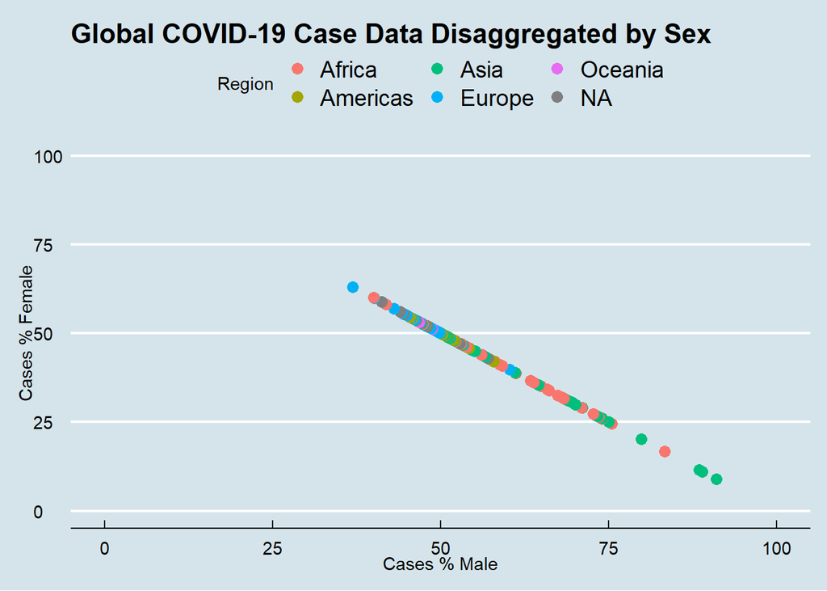

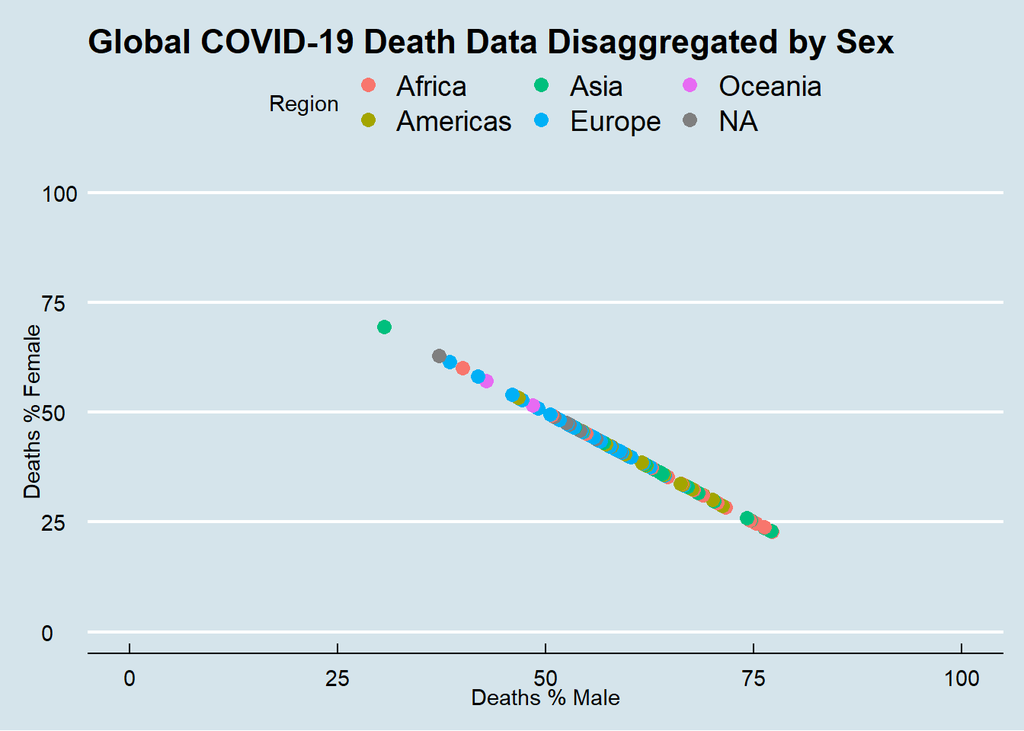

### Global Case Data

This stacked barplot gives us a slightly better sense of how these sex ratios vary between countries, but because a limited number of case data has been disaggregated by sex (many countries only started in recent months) we will also want to look at this by percentage. We can see that the US has the greatest number of COVID-19 cases disaggregated by sex, followed by India.

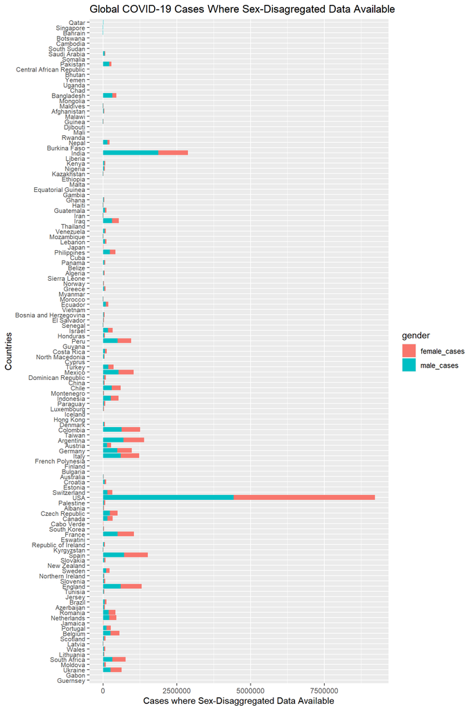

### Global Case Data By Percentage

This stacked barplot gives us a better sense of the sex ratios for COVID-19 cases where sex-disaggregated data are available and how these trends are not universal. For example, while the majority of cases in Qatar and Singapore have been male, countries like Guernsey, Gabon and the Ukraine have observed the opposite trend. This also gives us an understanding that for many countries, the ratio of male to female COVID-19 cases is nearly 1:1.

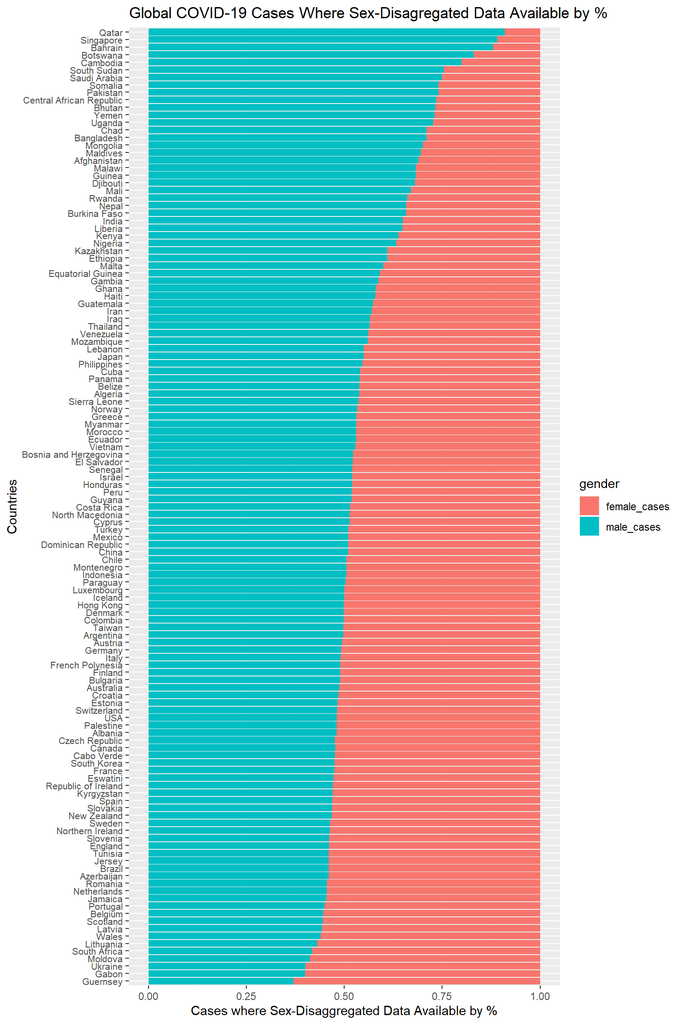

### Global Death Data

Our initial hypothesis was that we would see more male deaths from COVID-19 than female deaths for the reasons stated in the background section. This stacked bar chart provides some insight into country trends, but again, because sex-disaggregated death data is limited, we will also want to look at the data by percentage. We see that the US has the greatest number of deaths disaggregated by sex, followed by Brazil and Mexico – all of which have seen more men dying from COVID-19 than women.

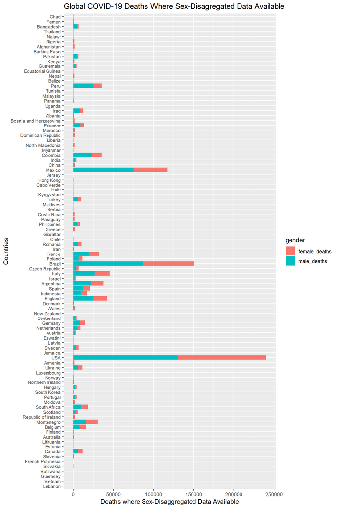

### Global Death Data By Percentage

This stacked barplot gives us a better sense of the sex ratios for COVID-19 deaths where sex-disaggregated data are available and how these trends are not universal. Unlike case data, the majority of countries have reported > 50% of their COVID-19 deaths being male with countries like Chad, Yemen and Bangladesh reporting over 75%. However, there are outliers - countries like Lebanon, Vietnam and Guernsey have reported more female deaths than male deaths from COVID-19. Future analyses ought to control for baseline population characteristics.

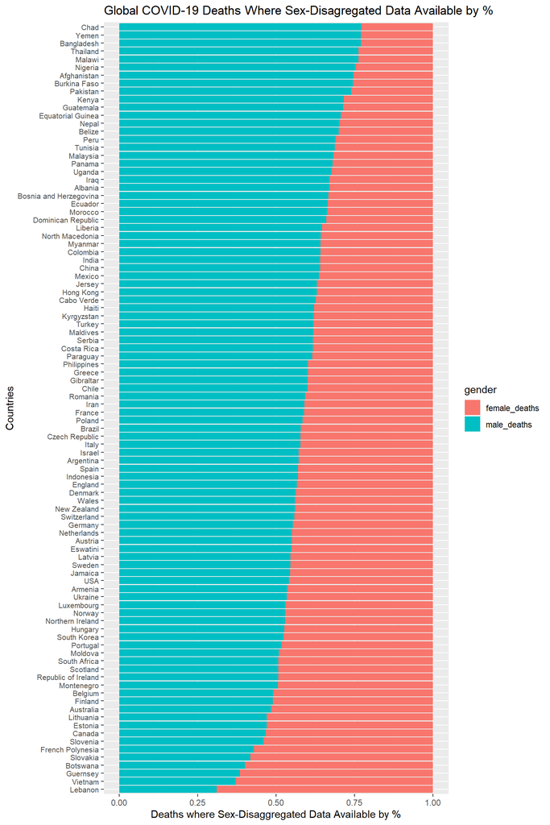

```
## [1] 85
```

```
## [1] 53
```

```
## [1] 48
```

### The Case for Sex-Disaggregated Data

While these visualizations illuminate some trends, we also see the need for more sex-disaggregated data to ascertain a better understanding of the true trends. According to Global Health 5050, as of December, there are 85 countries reporting complete sex-disaggregated COVID-19 data, 48 countries reporting partial data and 53 countries reporting no sex-disaggregated COVID-19 data.